# 220B_Final_Project

# Project Goal:

For this project, suppose a survey was conducted within San Francisco to investigate the number of individual consultations with pharmacists.

- Investigate how the number of consultations with a pharmacist is associated with other variables. As part of this investigation, develop a model for pharmacy managers to estimate the expected number of pharmacist consultations by a new customer within a 4 week period, if the pharmacy was provided with values of the other variables for that new customer.
- For the first person in this dataset, use your fitted model to estimate the probability distribution for his/her number of pharmacy consultations within a 4 week period, i.e., estimate the probability that his/her number of pharmacist consultations equals 0,1,2, etc.
- Clearly state and discuss your model(s) and assumptions, and also the limitations of your analysis in the context of this study. Within the discussion section, you may include any questions you would like to ask the people who designed the survey and collected these data

```r
pharmacy_data <- read.table("pharmacist.txt",header = T)

#inspect first few rows
head(pharmacy_data)
```

|  | pc | sex | age | income | lp | fp | fr | ill | ad | hs | ch1 | ch2 |
| --- | --- | --- | --- | --- | --- | --- | --- | --- | --- | --- | --- | --- |
| 1 | 0 | 1 | 0.19 | 0.45 | 1 | 0 | 0 | 0 | 0 | 0 | 0 | 0 |
| 2 | 0 | 1 | 0.72 | 0.25 | 0 | 0 | 1 | 2 | 14 | 5 | 0 | 1 |
| 3 | 0 | 0 | 0.47 | 1.30 | 1 | 0 | 0 | 2 | 0 | 1 | 0 | 1 |
| 4 | 0 | 0 | 0.27 | 0.90 | 1 | 0 | 0 | 0 | 0 | 0 | 0 | 0 |
| 5 | 0 | 0 | 0.19 | 0.15 | 0 | 0 | 0 | 2 | 0 | 5 | 0 | 0 |
| 6 | 0 | 0 | 0.72 | 0.45 | 0 | 0 | 1 | 3 | 0 | 0 | 1 | 0 |

### We are trying to predict pc, which is the number of consultations with a pharmacist in the past 4 weeks.

- pc variable represents counts, so we are modeling a Poisson distribution

## EDA

```r
library(reshape2)
long_df=melt(pharmacy_data)
```

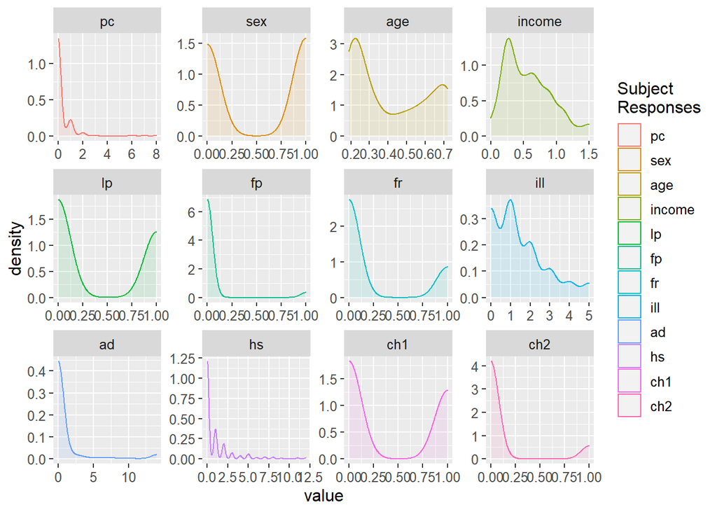

```r
kernel_plots <- ggplot(long_df, aes(value, colour = variable)) +
  geom_density(aes(fill=variable),alpha = 0.1)+
  facet_wrap(~variable, scales = "free") +
  labs(color = 'Subject\nResponses') + guides(fill=F) +
  theme(text = element_text(size = 12))

kernel_plots
```

Data either follows a bimodal, exponential, or skewed normal distribution.

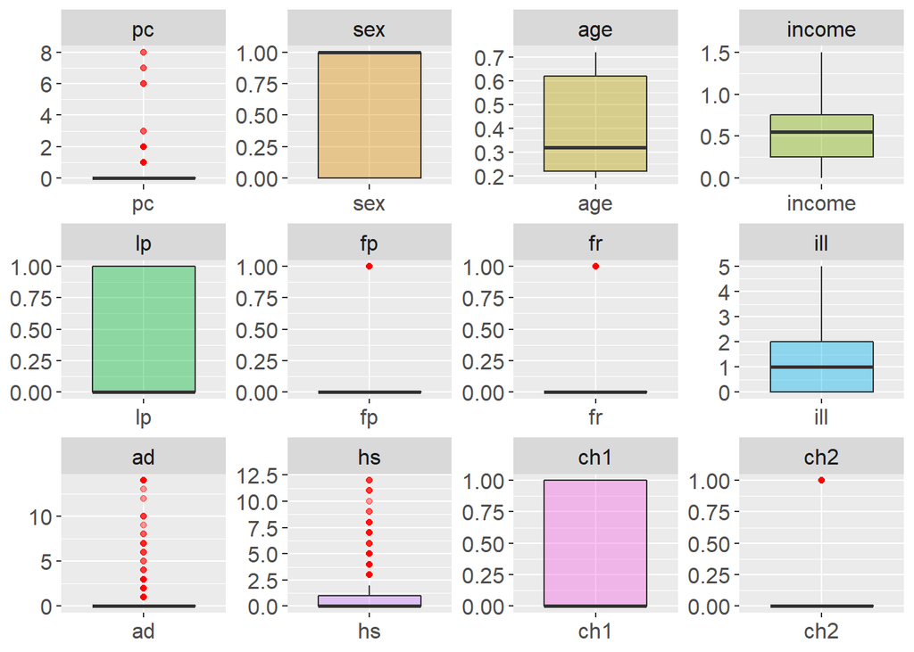

```r
cov.boxs <- ggplot(stack(pharmacy_data), aes(x = ind, y = values, fill = ind)) +
  geom_boxplot(outlier.color = 'red', alpha = 0.4) + facet_wrap(~ind, scales = 'free')+
  theme(legend.position = "none", axis.title = element_blank(), text = element_text(size = 15))
cov.boxs
```

```r
library(Hmisc)
```

```r
my_fn <- function(data, mapping, pts=list(), smt=list(), ...){
  ggplot(data = data, mapping = mapping, ...) +
    do.call(geom_point, pts) +
    do.call(geom_smooth, smt)
}

#p-values of correlations
rcorr(as.matrix(pharmacy_data), type = c('pearson'))
```

```
##           pc   sex   age income    lp    fp    fr   ill    ad    hs   ch1   ch2
## pc      1.00  0.14  0.17  -0.07  0.01 -0.07  0.10  0.16  0.46  0.23 -0.03  0.14
## sex     0.14  1.00  0.30  -0.26  0.09 -0.10  0.24  0.13  0.09  0.03  0.16 -0.01
## age     0.17  0.30  1.00  -0.29 -0.11 -0.16  0.64  0.26  0.17  0.11  0.33  0.15
## income -0.07 -0.26 -0.29   1.00  0.28 -0.15 -0.39 -0.17 -0.09 -0.13 -0.08 -0.06
## lp      0.01  0.09 -0.11   0.28  1.00 -0.18 -0.46 -0.07 -0.10 -0.05  0.01 -0.11
## fp     -0.07 -0.10 -0.16  -0.15 -0.18  1.00 -0.13 -0.09 -0.03  0.06 -0.09 -0.05
## fr      0.10  0.24  0.64  -0.39 -0.46 -0.13  1.00  0.32  0.17  0.19  0.19  0.26
## ill     0.16  0.13  0.26  -0.17 -0.07 -0.09  0.32  1.00  0.16  0.27  0.20  0.22
## ad      0.46  0.09  0.17  -0.09 -0.10 -0.03  0.17  0.16  1.00  0.30 -0.04  0.22
## hs      0.23  0.03  0.11  -0.13 -0.05  0.06  0.19  0.27  0.30  1.00  0.00  0.21
## ch1    -0.03  0.16  0.33  -0.08  0.01 -0.09  0.19  0.20 -0.04  0.00  1.00 -0.31
## ch2     0.14 -0.01  0.15  -0.06 -0.11 -0.05  0.26  0.22  0.22  0.21 -0.31  1.00
##
## n= 500
##
##
## P
##        pc     sex    age    income lp     fp     fr     ill    ad     hs
## pc            0.0016 0.0000 0.1291 0.7913 0.1051 0.0217 0.0002 0.0000 0.0000
## sex    0.0016        0.0000 0.0000 0.0395 0.0242 0.0000 0.0047 0.0359 0.4389
## age    0.0000 0.0000        0.0000 0.0143 0.0003 0.0000 0.0000 0.0001 0.0139
## income 0.1291 0.0000 0.0000        0.0000 0.0005 0.0000 0.0000 0.0443 0.0043
## lp     0.7913 0.0395 0.0143 0.0000        0.0000 0.0000 0.1080 0.0207 0.2329
## fp     0.1051 0.0242 0.0003 0.0005 0.0000        0.0050 0.0482 0.5104 0.1855
## fr     0.0217 0.0000 0.0000 0.0000 0.0000 0.0050        0.0000 0.0002 0.0000
## ill    0.0002 0.0047 0.0000 0.0000 0.1080 0.0482 0.0000        0.0003 0.0000
## ad     0.0000 0.0359 0.0001 0.0443 0.0207 0.5104 0.0002 0.0003        0.0000
## hs     0.0000 0.4389 0.0139 0.0043 0.2329 0.1855 0.0000 0.0000 0.0000
## ch1    0.5712 0.0003 0.0000 0.0731 0.8262 0.0378 0.0000 0.0000 0.3720 0.9689
## ch2    0.0024 0.9022 0.0009 0.1878 0.0137 0.2357 0.0000 0.0000 0.0000 0.0000
##        ch1    ch2
## pc     0.5712 0.0024
## sex    0.0003 0.9022
## age    0.0000 0.0009
## income 0.0731 0.1878
## lp     0.8262 0.0137
## fp     0.0378 0.2357
## fr     0.0000 0.0000
## ill    0.0000 0.0000
## ad     0.3720 0.0000
## hs     0.9689 0.0000
## ch1           0.0000
## ch2    0.0000
```

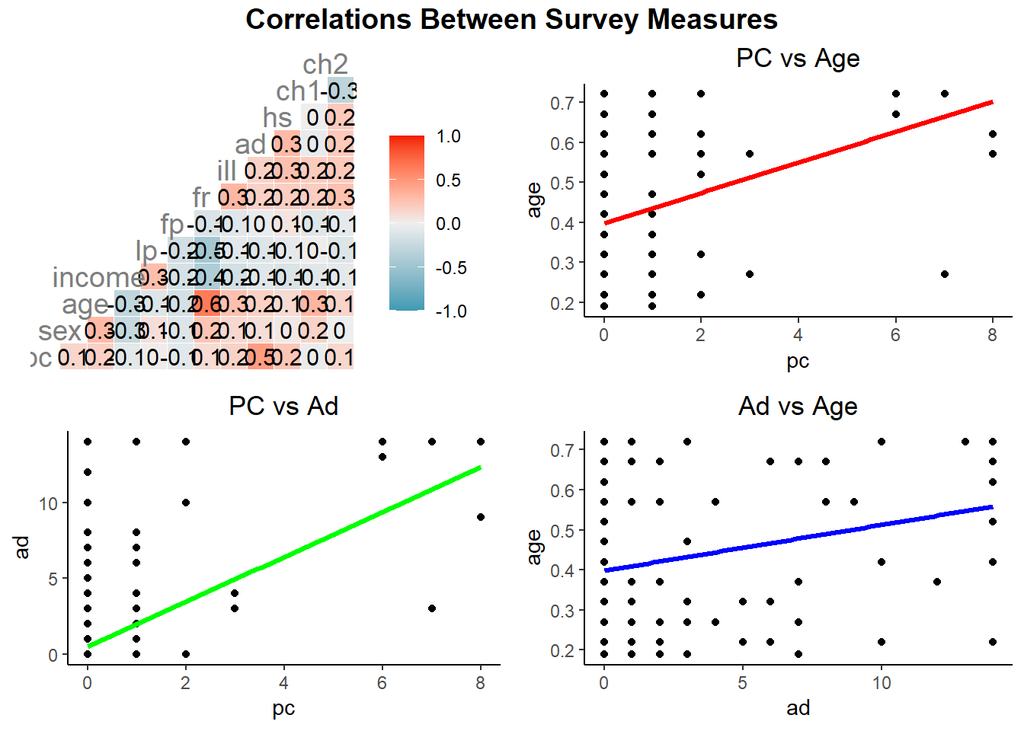

```r
all_corr <- ggcorr(pharmacy_data, geom = "tile", label = T, hjust = .8, size = 5, color = "grey50")

# only plot the interesting correlations between pc, age, ad
p1 <- ggplot(pharmacy_data, aes(x = pc, y = age)) +
  geom_point() + geom_smooth(method = 'lm', se = F, size = 1.2, color = 'red', alpha = 0.5)+
  labs(title = 'PC vs Age') + theme_classic() + theme(plot.title = element_text(hjust = 0.5))

p2 <- ggplot(pharmacy_data, aes(x = pc, y = ad)) +
  geom_point() + geom_smooth(method = 'lm', se = F, size = 1.2, color = 'green', alpha = 0.5) +
  labs(title = 'PC vs Ad') + theme_classic() +  theme(plot.title = element_text(hjust = 0.5))

p3 <- ggplot(pharmacy_data, aes(x = ad, y = age)) +
  geom_point() + geom_smooth(method = 'lm', se = F, size = 1.2, color = 'blue', alpha = 0.5) +
  labs(title = 'Ad vs Age') + theme_classic() +  theme(plot.title = element_text(hjust = 0.5))

int_corr <- ggarrange(all_corr,p1,p2,p3, nrow = 2, ncol = 2)
annotate_figure(int_corr, top =text_grob ("Correlations Between Survey Measures", face = "bold", size = 14))
```

# Being Modeling

## Trying out a poisson model

```r
fit1 <- glm(pc ~ ., family = 'poisson', data = pharmacy_data)

summary(fit1)
```

```
##
## Call:
## glm(formula = pc ~ ., family = "poisson", data = pharmacy_data)
##
## Deviance Residuals:
##     Min       1Q   Median       3Q      Max
## -2.8826  -0.6614  -0.5196  -0.3943   5.3944
##
## Coefficients:
##              Estimate Std. Error z value Pr(>|z|)
## (Intercept)  -2.70287    0.34489  -7.837 4.62e-15 ***
## sex           0.51312    0.20629   2.487  0.01287 *
## age           1.58812    0.56132   2.829  0.00467 **
## income        0.01754    0.27031   0.065  0.94827
## lp            0.06920    0.24701   0.280  0.77938
## fp          -15.42236  662.05857  -0.023  0.98142
## fr           -0.37376    0.30052  -1.244  0.21361
## ill           0.18042    0.05596   3.224  0.00126 **
## ad            0.13709    0.01622   8.453  < 2e-16 ***
## hs            0.08078    0.03112   2.596  0.00943 **
## ch1          -0.46214    0.21825  -2.118  0.03422 *
## ch2          -0.30734    0.26999  -1.138  0.25499
## ---
## Signif. codes:  0 '***' 0.001 '**' 0.01 '*' 0.05 '.' 0.1 ' ' 1
##
## (Dispersion parameter for poisson family taken to be 1)
##
##     Null deviance: 598.72  on 499  degrees of freedom
## Residual deviance: 402.55  on 488  degrees of freedom
## AIC: 631.59
##
## Number of Fisher Scoring iterations: 15
```

```r
#check phi for over dispersion
rp <- residuals(fit1,type = 'pearson') #phi tilde numerator

phi_hat <- fit1$deviance/fit1$df.residual
phi_tilde <- sum(rp^2)/fit1$df.residual

fit1.phi <- as.data.frame(cbind('hat'=phi_hat,'tilde'=phi_tilde))
fit1.phi
```

| hat | tilde |
| --- | --- |
| 0.8249067 | 1.337288 |

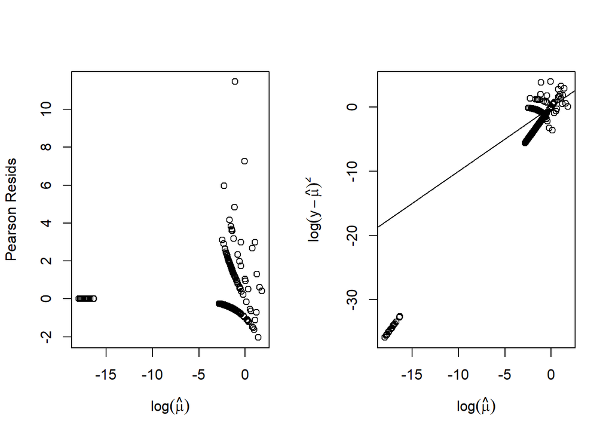

```r
#check for overdispersion using residuals
fv <- fitted(fit1)

par(mfrow = c(1,2))

plot(log(fv), rp, xlab = expression(log(hat(mu))),
     ylab = "Pearson Resids")
plot(log(fv), log(residuals(fit1, type = 'response')^2), xlab = expression(log(hat(mu))),
     ylab = expression(log(y - hat(mu))^2))
abline(0,1)
```

First pass of the model indicates that sex, age, ill, ad, hs, and ch1 are all significant predictors. Deviance diagnostics suggest that poisson is the true random component (phi hat < 1, phi tilde > 1). Residual plots suggest that we may have some outliers and potential over dispersion, though.

### Trying to lower AIC

```r
library(MASS)
fit2 <- stepAIC(fit1, direction = 'both',trace =F)
summary(fit2)
```

```
##
## Call:
## glm(formula = pc ~ sex + age + fp + fr + ill + ad + hs + ch1,
##     family = "poisson", data = pharmacy_data)
##
## Deviance Residuals:
##     Min       1Q   Median       3Q      Max
## -2.9370  -0.6606  -0.5290  -0.4054   5.4916
##
## Coefficients:
##              Estimate Std. Error z value Pr(>|z|)
## (Intercept)  -2.68057    0.25243 -10.619  < 2e-16 ***
## sex           0.53194    0.19790   2.688  0.00719 **
## age           1.54717    0.52792   2.931  0.00338 **
## fp          -15.47124  671.79675  -0.023  0.98163
## fr           -0.50066    0.20488  -2.444  0.01454 *
## ill           0.16715    0.05365   3.116  0.00184 **
## ad            0.13338    0.01571   8.488  < 2e-16 ***
## hs            0.07476    0.02942   2.542  0.01104 *
## ch1          -0.32564    0.18335  -1.776  0.07573 .
## ---
## Signif. codes:  0 '***' 0.001 '**' 0.01 '*' 0.05 '.' 0.1 ' ' 1
##
## (Dispersion parameter for poisson family taken to be 1)
##
##     Null deviance: 598.72  on 499  degrees of freedom
## Residual deviance: 403.93  on 491  degrees of freedom
## AIC: 626.97
##
## Number of Fisher Scoring iterations: 15
```

```r
anova(fit1,fit2, test = 'Chi')
```

|  | Resid. Df | Resid. Dev | Df | Deviance | Pr(>Chi) |
| --- | --- | --- | --- | --- | --- |
| 1 | 488 | 402.5545 | NA | NA | NA |
| 2 | 491 | 403.9258 | -3 | -1.371343 | 0.7122656 |

### Set some variables as factors

```r
pharmacy_data$sex <- factor(pharmacy_data$sex, labels = c('M','F'))
pharmacy_data$lp <- factor(pharmacy_data$lp, labels = c('uncovered','covered'))
pharmacy_data$fp <- factor(pharmacy_data$fp, labels = c('nonprivatePharm','privatePharm'))
pharmacy_data$fr <- factor(pharmacy_data$fr, labels = c('nonprivate','private'))
pharmacy_data$ch1 <- factor(pharmacy_data$ch1, labels = c('nonChronic1','chronicNoLim'))
pharmacy_data$ch2 <- factor(pharmacy_data$ch2, labels = c('nonChronic2','chronicLim'))
```

```r
fit3 <- glm(pc ~ ., data = pharmacy_data, family = 'poisson')
summary(fit3)
```

```
##
## Call:
## glm(formula = pc ~ ., family = "poisson", data = pharmacy_data)
##
## Deviance Residuals:
##     Min       1Q   Median       3Q      Max
## -2.8826  -0.6614  -0.5196  -0.3943   5.3944
##
## Coefficients:
##                  Estimate Std. Error z value Pr(>|z|)
## (Intercept)      -2.70287    0.34489  -7.837 4.62e-15 ***
## sexF              0.51312    0.20629   2.487  0.01287 *
## age               1.58812    0.56132   2.829  0.00467 **
## income            0.01754    0.27031   0.065  0.94827
## lpcovered         0.06920    0.24701   0.280  0.77938
## fpprivatePharm  -15.42236  662.05857  -0.023  0.98142
## frprivate        -0.37376    0.30052  -1.244  0.21361
## ill               0.18042    0.05596   3.224  0.00126 **
## ad                0.13709    0.01622   8.453  < 2e-16 ***
## hs                0.08078    0.03112   2.596  0.00943 **
## ch1chronicNoLim  -0.46214    0.21825  -2.118  0.03422 *
## ch2chronicLim    -0.30734    0.26999  -1.138  0.25499
## ---
## Signif. codes:  0 '***' 0.001 '**' 0.01 '*' 0.05 '.' 0.1 ' ' 1
##
## (Dispersion parameter for poisson family taken to be 1)
##
##     Null deviance: 598.72  on 499  degrees of freedom
## Residual deviance: 402.55  on 488  degrees of freedom
## AIC: 631.59
##
## Number of Fisher Scoring iterations: 15
```

```r
fit3.2 <- stepAIC(fit3, direction = 'both',trace = F)
summary(fit3.2)
```

```
##
## Call:
## glm(formula = pc ~ sex + age + fp + fr + ill + ad + hs + ch1,
##     family = "poisson", data = pharmacy_data)
##
## Deviance Residuals:
##     Min       1Q   Median       3Q      Max
## -2.9370  -0.6606  -0.5290  -0.4054   5.4916
##
## Coefficients:
##                  Estimate Std. Error z value Pr(>|z|)
## (Intercept)      -2.68057    0.25243 -10.619  < 2e-16 ***
## sexF              0.53194    0.19790   2.688  0.00719 **
## age               1.54717    0.52792   2.931  0.00338 **
## fpprivatePharm  -15.47124  671.79675  -0.023  0.98163
## frprivate        -0.50066    0.20488  -2.444  0.01454 *
## ill               0.16715    0.05365   3.116  0.00184 **
## ad                0.13338    0.01571   8.488  < 2e-16 ***
## hs                0.07476    0.02942   2.542  0.01104 *
## ch1chronicNoLim  -0.32564    0.18335  -1.776  0.07573 .
## ---
## Signif. codes:  0 '***' 0.001 '**' 0.01 '*' 0.05 '.' 0.1 ' ' 1
##
## (Dispersion parameter for poisson family taken to be 1)
##
##     Null deviance: 598.72  on 499  degrees of freedom
## Residual deviance: 403.93  on 491  degrees of freedom
## AIC: 626.97
##
## Number of Fisher Scoring iterations: 15
```

```r
anova(fit2,fit3.2, test = 'Chisq')
```

|  | Resid. Df | Resid. Dev | Df | Deviance | Pr(>Chi) |
| --- | --- | --- | --- | --- | --- |
| 1 | 491 | 403.9258 | NA | NA | NA |
| 2 | 491 | 403.9258 | 0 | 0 | NA |

- Switching variables to categorical doesn’t seem to be having an effect. Try interactions

### Testing Interactions

```r
fit4 <- stepAIC(fit1, ~ .^2, direction = 'both', trace = F)
summary(fit4)
```

```
##
## Call:
## glm(formula = pc ~ sex + age + income + lp + fp + fr + ill +
##     ad + hs + ch1 + ch2 + ad:ch2 + income:lp + ill:hs + fr:ad +
##     lp:hs + fr:hs + age:hs + sex:age + sex:hs, family = "poisson",
##     data = pharmacy_data)
##
## Deviance Residuals:
##     Min       1Q   Median       3Q      Max
## -2.3812  -0.6301  -0.4524  -0.2011   4.9363
##
## Coefficients:
##                   Estimate Std. Error z value Pr(>|z|)
## (Intercept)       -1.94496    0.54781  -3.550 0.000385 ***
## sexF              -0.23429    0.50878  -0.460 0.645167
## age               -2.88687    1.31065  -2.203 0.027621 *
## income            -0.74032    0.46581  -1.589 0.111989
## lpcovered          0.09547    0.53365   0.179 0.858018
## fpprivatePharm   -17.11155  880.05148  -0.019 0.984487
## frprivate          0.52528    0.48187   1.090 0.275676
## ill                0.33334    0.08530   3.908 9.32e-05 ***
## ad                 0.19614    0.02323   8.444  < 2e-16 ***
## hs                 0.31873    0.13147   2.424 0.015336 *
## ch1chronicNoLim   -0.39687    0.23543  -1.686 0.091854 .
## ch2chronicLim      0.37729    0.31406   1.201 0.229622
## ad:ch2chronicLim  -0.09833    0.03390  -2.901 0.003724 **
## income:lpcovered   1.14959    0.60138   1.912 0.055931 .
## ill:hs            -0.06948    0.02438  -2.850 0.004366 **
## frprivate:ad      -0.05689    0.03466  -1.641 0.100742
## lpcovered:hs      -0.46141    0.12877  -3.583 0.000339 ***
## frprivate:hs      -0.48449    0.12661  -3.827 0.000130 ***
## age:hs             0.95351    0.28063   3.398 0.000679 ***
## sexF:age           3.13971    1.23413   2.544 0.010957 *
## sexF:hs           -0.24511    0.10052  -2.438 0.014753 *
## ---
## Signif. codes:  0 '***' 0.001 '**' 0.01 '*' 0.05 '.' 0.1 ' ' 1
##
## (Dispersion parameter for poisson family taken to be 1)
##
##     Null deviance: 598.72  on 499  degrees of freedom
## Residual deviance: 342.90  on 479  degrees of freedom
## AIC: 589.94
##
## Number of Fisher Scoring iterations: 16
```

```r
anova(fit2,fit4, test = 'Chi')
```

|  | Resid. Df | Resid. Dev | Df | Deviance | Pr(>Chi) |
| --- | --- | --- | --- | --- | --- |
| 1 | 491 | 403.9258 | NA | NA | NA |
| 2 | 479 | 342.8961 | 12 | 61.02975 | 1.464199e-08 |

Model with interaction terms explains significantly more of the variation in pc, also has a lower AIC. Much more complex, though.

```r
rp <- residuals(fit4,type = 'pearson') #phi tilde numerator

phi_hat <- fit4$deviance/fit4$df.residual
phi_tilde <- sum(rp^2)/fit4$df.residual

fit4.phi <- as.data.frame(cbind('hat'=phi_hat,'tilde'=phi_tilde))
fit4.phi
```

| hat | tilde |
| --- | --- |
| 0.7158582 | 1.325755 |

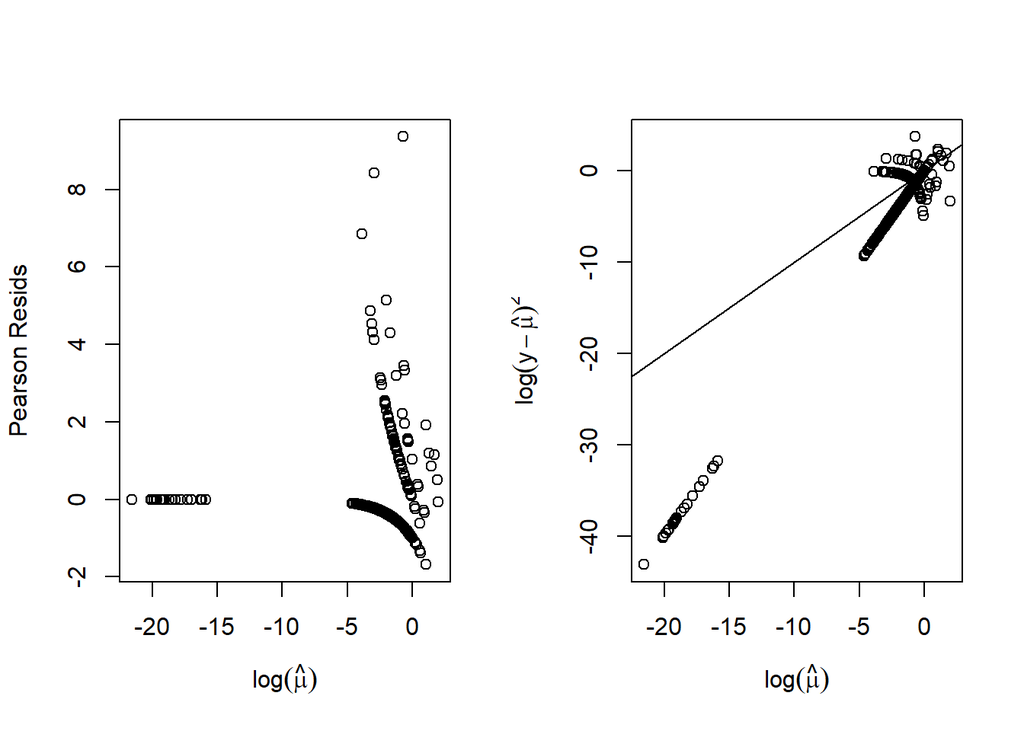

```r
#check for overdispersion using residuals
fv <- fitted(fit4)

par(mfrow = c(1,2))

plot(log(fv), rp, xlab = expression(log(hat(mu))),
     ylab = "Pearson Resids")
plot(log(fv), log(residuals(fit4, type = 'response')^2), xlab = expression(log(hat(mu))),
     ylab = expression(log(y - hat(mu))^2))
abline(0,1)
```

```r
library(boot)
```

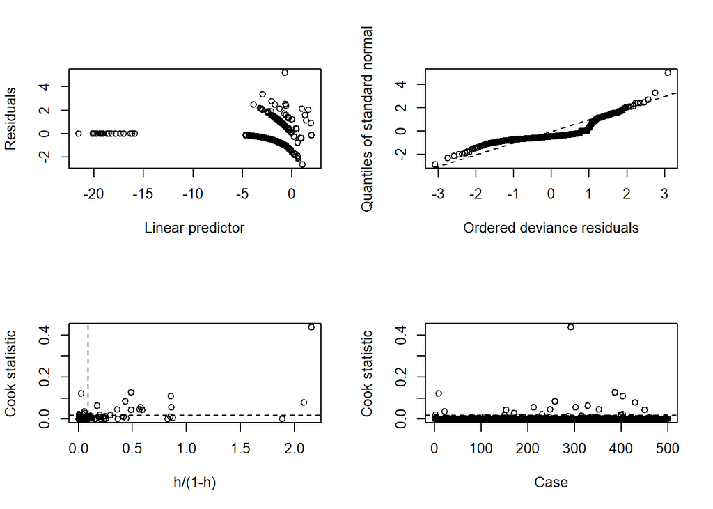

```r
glm.diag.plots(fit4)
```

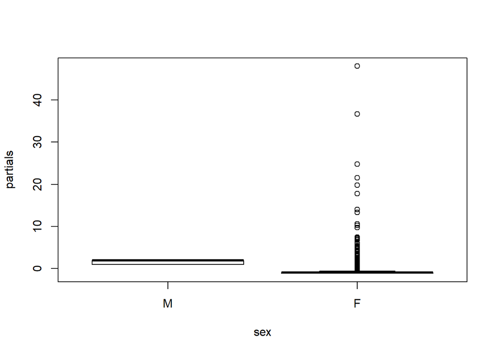

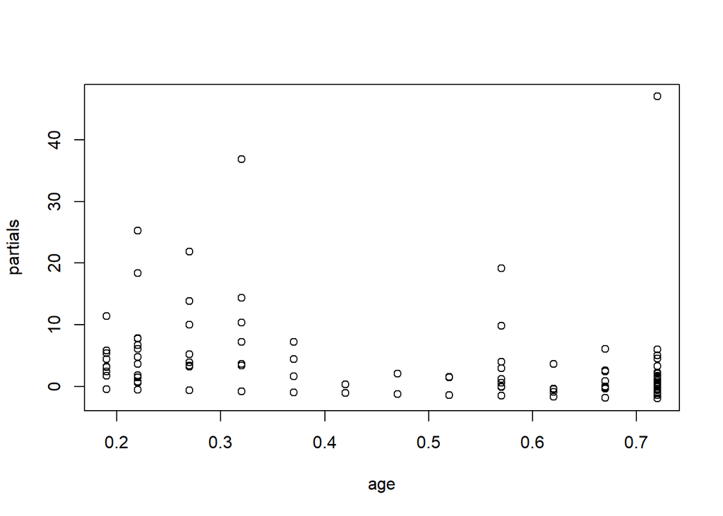

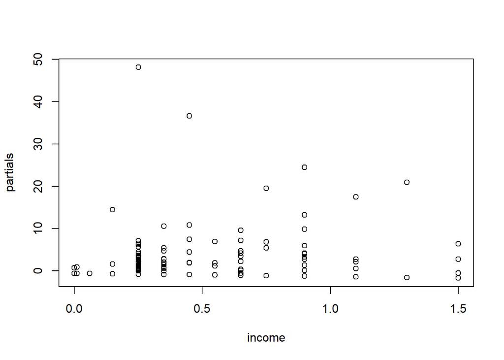

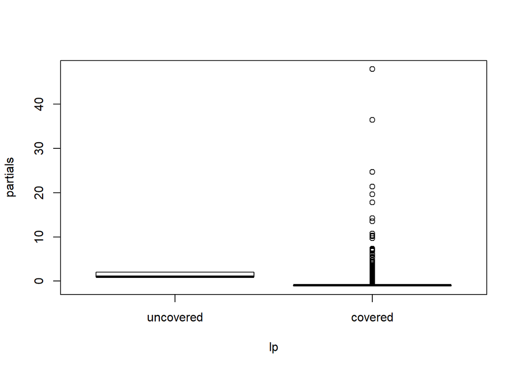

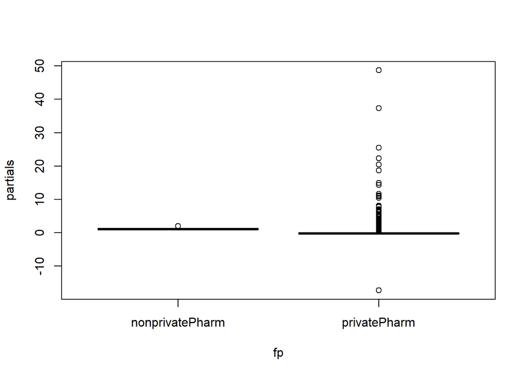

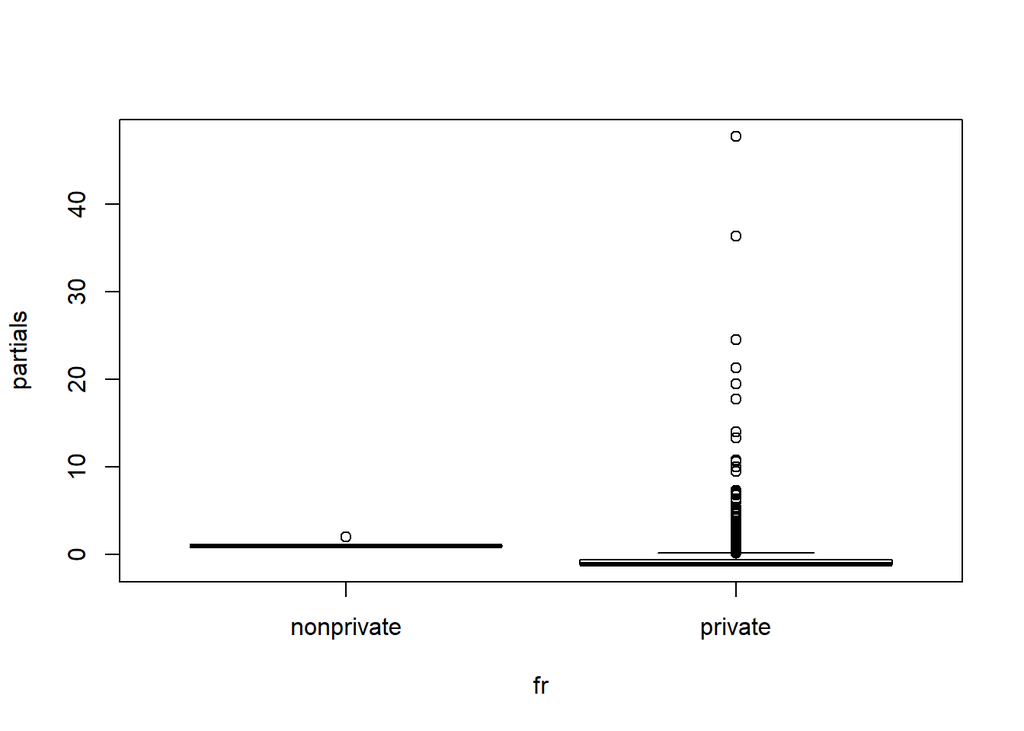

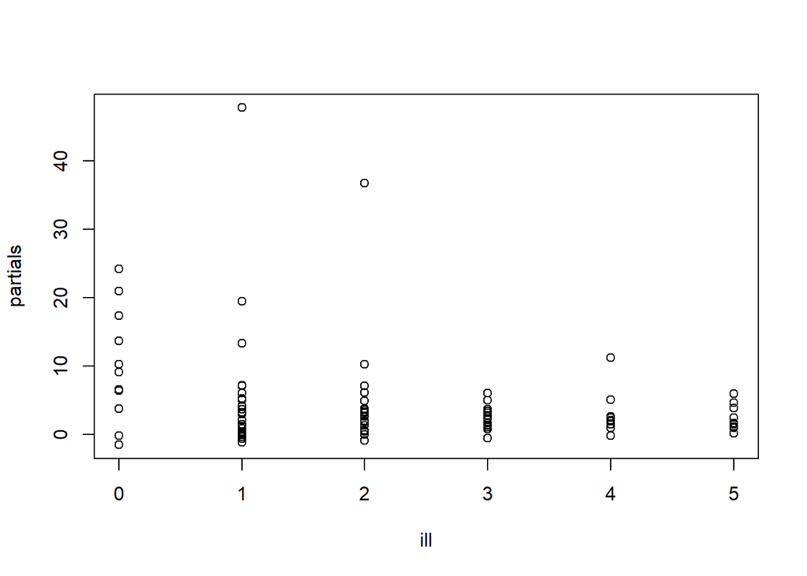

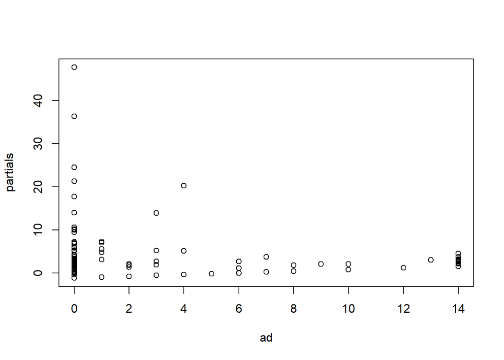

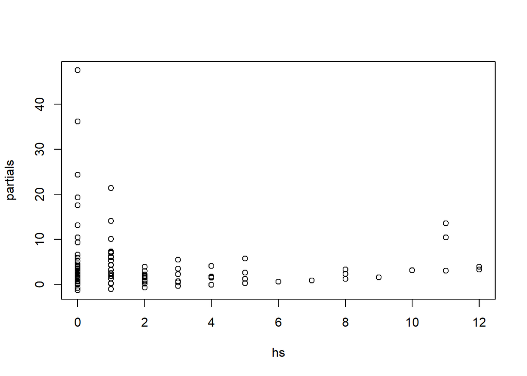

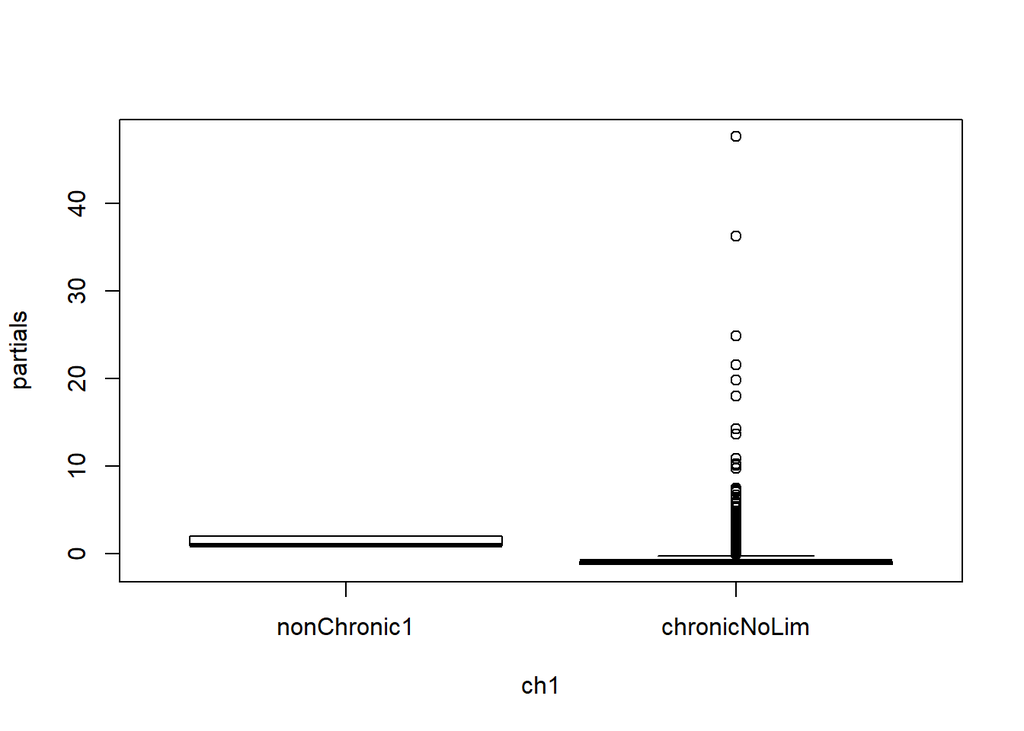

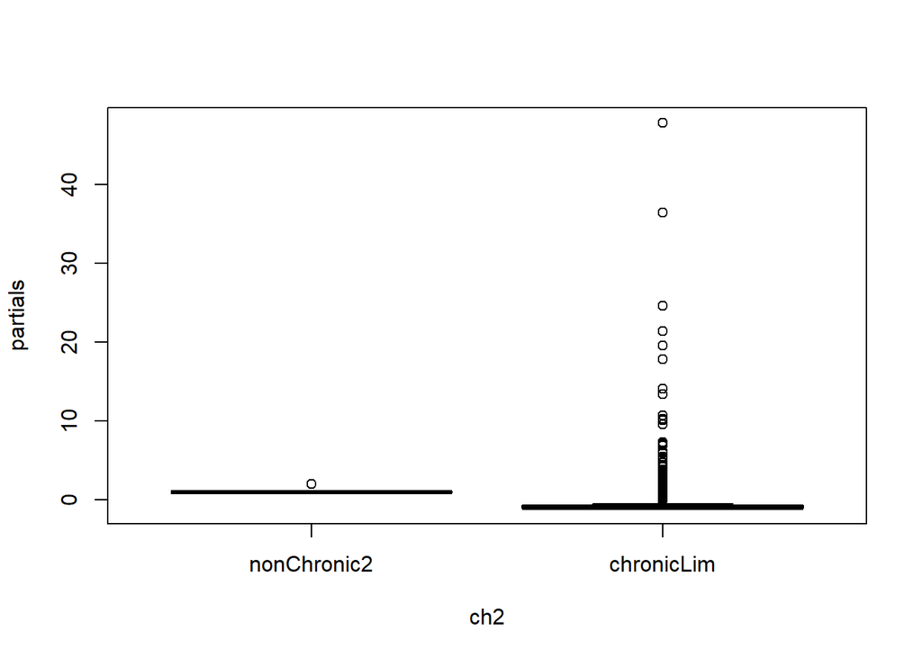

```r
fit4.partials <- residuals(fit4,type = 'partial')

f <- sapply(pharmacy_data, is.factor)
#par(mfrow = c(5,4))
for (iCol in colnames(pharmacy_data)){
  col_pos <- match(iCol, colnames(fit4.partials))
  if (is.na(col_pos)){
    next
  }

  if (f[iCol]){
    boxplot(pharmacy_data[,iCol], fit4.partials[,col_pos], ylab='partials', names=levels(pharmacy_data[,iCol]), xlab = iCol)
  } else {
    plot(pharmacy_data[,iCol],fit4.partials[,col_pos], ylab='partials', xlab = iCol)
    #lines(smooth.spline(pharmacy_data[,iCol],fit4.partials[,iCol]), col = 'red', tol = 10000, lwd = 2,
          #lty = 2)
  }

}
```

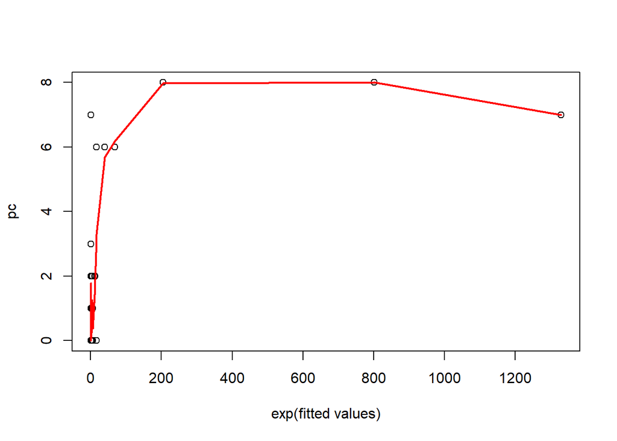

```r
plot(exp(fv), pharmacy_data[,'pc'], ylab = 'pc', xlab = 'exp(fitted values)')
lines(smooth.spline(exp(fv),pharmacy_data[,'pc']), col = 'red', lwd = 2)
```

```r
#identify(exp(fv), pharmacy_data[,'pc'], labels = name)
```

### Check for variance inflation